# Untitled

Kenigbolo Meya Stephen

March 14, 2016

1. Construct an FP-tree using the same data set as last week (use the support count threshold smin = 2). Explain all the steps of the tree construction and draw a resulting tree. Based on this tree answer the questions: how many transactions contain {E,F} and {C,H} ?

```r
library(arules)
abcset <- read.transactions("C:/Users/Kenigbolo PC/Desktop/Data Mining/abcset.csv", rm.duplicates= FALSE, format="basket", sep=",")


inspect(abcset)
```

```
##    items
## 1  {A,B,C,F,H}
## 2  {C,E,F,H}
## 3  {B,D,E}
## 4  {A,C,F,H}
## 5  {A,E,F}
## 6  {B,D,H}
## 7  {B,C,D,E,F}
## 8  {A,C,E,H}
## 9  {A,E,G}
## 10 {B,E,H}
```

{E,F} = 3 {H,C} = 4

2. Evaluate various interestingness measures for association rules. Generate randomly a broad range of various 2x2 contingency tables (f11, f10, f01, f00) for N=10,000 items. Sample the space so that each cell individually, in pairs, or triples is larger than “others”. In this way sample at least 10,000 different possible contingency tables. Calculate 5 various scores based on those data (feel free to select) and report 10 top 2x2 tables that are the “best” according to that measure. Use rows to represent the 4 numbers; and if useful, also the marginal sums and N.

```r
randomtablevalues <- sample(1:4,1000,rep=TRUE,prob=c(.2,.3,.2,.3))
table(randomtablevalues)
```

```
## randomtablevalues
##   1   2   3   4
## 203 303 196 298
```

```r
func = ceiling(runif(10000, 0,1000))
randomGen = t(sapply(func, function(z) c(z, 4*z, 3*z, 2*z)))

colnames(randomGen) <- c("f11","f01","f10","f00")

F1plus <- rowSums(randomGen[, c(1, 3)])
F0plus <- rowSums(randomGen[, c(2, 4)])
Fplus1 <- rowSums(randomGen[, c(1, 2)])
Fplus0 <- rowSums(randomGen[, c(3, 4)])
T <- rowSums(randomGen[, c(1, 2, 3, 4)])

randomGen <- cbind(randomGen, F1plus)
randomGen <- cbind(randomGen, F0plus)
randomGen <- cbind(randomGen, Fplus1 )
randomGen <- cbind(randomGen, Fplus0 )
randomGen <- cbind(randomGen, T )


oddsRatiofunction <- function(f11,f01,f10,f00) {
    oddsratio <- ((f11/f00)/(f10/f01))
    return(oddsratio)
}

jaccard <- function(f11,F1plus,Fplus1) {
  jaccard <- (f11/(F1plus+Fplus1-f11))
  return(jaccard)
}

laplace <- function(f11,F1plus) {
  laplace <- ((f11+1)/(F1plus+2))
  return (laplace)
}

certainityFactor <- function(f11,F1plus,Fplus1){
  certfact <-  (((f11/F1plus)-(Fplus1/10000))/(1-(Fplus1/10000)))
  return (certfact)
}

addedValue <- function(f11,F1plus,Fplus1){
  addedvalue <-  (((f11/F1plus)-(Fplus1/10000)))
  return (addedvalue)
}

jaccard <- jaccard(randomGen[,c(1)], randomGen[,c(5)], randomGen[,c(7)])
oddRatio <- oddsRatiofunction(randomGen[,c(1)], randomGen[,c(2)], randomGen[,c(3)], randomGen[,c(4)])
laplace <- laplace(randomGen[,c(1)], randomGen[,c(5)])
certainityFactor <- certainityFactor(randomGen[,c(1)],randomGen[,c(5)], randomGen[,c(7)])
addedValue <- addedValue(randomGen[,c(1)],randomGen[,c(5)], randomGen[,c(7)])


randomGen <- cbind(randomGen, oddRatio)
randomGen <- cbind(randomGen, jaccard)
randomGen <- cbind(randomGen, laplace)
randomGen <- cbind(randomGen, certainityFactor)
randomGen <- cbind(randomGen, addedValue)


top10 <- subset(randomGen, laplace < 0.27)
head(top10, 10)
```

```
##       f11  f01  f10  f00 F1plus F0plus Fplus1 Fplus0    T  oddRatio
##  [1,] 464 1856 1392  928   1856   2784   2320   2320 4640 0.6666667
##  [2,] 921 3684 2763 1842   3684   5526   4605   4605 9210 0.6666667
##  [3,] 148  592  444  296    592    888    740    740 1480 0.6666667
##  [4,] 787 3148 2361 1574   3148   4722   3935   3935 7870 0.6666667
##  [5,] 233  932  699  466    932   1398   1165   1165 2330 0.6666667
##  [6,] 606 2424 1818 1212   2424   3636   3030   3030 6060 0.6666667
##  [7,] 887 3548 2661 1774   3548   5322   4435   4435 8870 0.6666667
##  [8,] 556 2224 1668 1112   2224   3336   2780   2780 5560 0.6666667
##  [9,] 656 2624 1968 1312   2624   3936   3280   3280 6560 0.6666667
## [10,] 659 2636 1977 1318   2636   3954   3295   3295 6590 0.6666667
##       jaccard   laplace certainityFactor addedValue
##  [1,]   0.125 0.2502691       0.02343750     0.0180
##  [2,]   0.125 0.2501356      -0.39017609    -0.2105
##  [3,]   0.125 0.2508418       0.19006479     0.1760
##  [4,]   0.125 0.2501587      -0.23660346    -0.1435
##  [5,]   0.125 0.2505353       0.15110357     0.1335
##  [6,]   0.125 0.2502061      -0.07604017    -0.0530
##  [7,]   0.125 0.2501408      -0.34770889    -0.1935
##  [8,]   0.125 0.2502246      -0.03878116    -0.0280
##  [9,]   0.125 0.2501904      -0.11607143    -0.0780
## [10,]   0.125 0.2501895      -0.11856823    -0.0795
```

3. Compare interestingness measures starting from various fixed examples of (f11, f10, f01, f00) and experimenting with each of the four values - by increasing or decreasing it, one at a time.

```r
newRandGen <- head(randomGen, 1)
print(newRandGen)
```

```
##      f11  f01  f10 f00 F1plus F0plus Fplus1 Fplus0    T  oddRatio jaccard
## [1,] 464 1856 1392 928   1856   2784   2320   2320 4640 0.6666667   0.125
##        laplace certainityFactor addedValue
## [1,] 0.2502691        0.0234375      0.018
```

```r
newRandGen[1, 1] + 10
```

```
## f11
## 474
```

```r
addedValuefunc <- function(f11,F1plus,Fplus1){
  addedvalue <-  (((f11/F1plus)-(Fplus1/10000)))
  return (addedvalue)
}
addedValue <- addedValuefunc(newRandGen[,c(1)],newRandGen[,c(5)], newRandGen[,c(7)])
print(addedValue)
```

```
##   f11
## 0.018
```

```r
newRandGen[1, 2] + 10
```

```
##  f01
## 1866
```

```r
addedValue <- addedValuefunc(newRandGen[,c(1)],newRandGen[,c(5)], newRandGen[,c(7)])
print(addedValue)
```

```
##   f11
## 0.018
```

```r
newRandGen[1, 3] + 10
```

```
##  f10
## 1402
```

```r
addedValue <- addedValuefunc(newRandGen[,c(1)],newRandGen[,c(5)], newRandGen[,c(7)])
print(addedValue)
```

```
##   f11
## 0.018
```

```r
newRandGen[1, 4] + 10
```

```
## f00
## 938
```

```r
addedValue <- addedValuefunc(newRandGen[,c(1)],newRandGen[,c(5)], newRandGen[,c(7)])
print(addedValue)
```

```
##   f11
## 0.018
```

4. Install R packages arules and arulesViz Get the Titanic survival data from https://courses.cs.ut.ee/MTAT.03.183/2014_spring/uploads/Main/titanic.txt

Make sure to explore all these commands, vary parameters, read the manual … Try to vary them to provide nice interpretable outputs. See also 6. and 7.

```r
library(arulesViz)
library(arulesViz)

titanic <- read.table( "C:/Users/Kenigbolo PC/Desktop/Data Mining/titanic.txt", sep = ',' , header = TRUE)

#observe the data
##first 6 observations
head(titanic)
```

```
##   Class  Sex   Age Survived
## 1   3rd Male Child       No
## 2   3rd Male Child       No
## 3   3rd Male Child       No
## 4   3rd Male Child       No
## 5   3rd Male Child       No
## 6   3rd Male Child       No
```

```r
#types of features
str(titanic)
```

```
## 'data.frame':    2201 obs. of  4 variables:
##  $ Class   : Factor w/ 4 levels "1st","2nd","3rd",..: 3 3 3 3 3 3 3 3 3 3 ...
##  $ Sex     : Factor w/ 2 levels "Female","Male": 2 2 2 2 2 2 2 2 2 2 ...
##  $ Age     : Factor w/ 2 levels "Adult","Child": 2 2 2 2 2 2 2 2 2 2 ...
##  $ Survived: Factor w/ 2 levels "No","Yes": 1 1 1 1 1 1 1 1 1 1 ...
```

```r
#dimensionality of the data
dim(titanic)
```

```
## [1] 2201    4
```

```r
#load package for frequent set mining
library(arules)


#run apriori algorithm with default settings
rules = apriori(titanic)
```

```
## Apriori
##
## Parameter specification:
##  confidence minval smax arem  aval originalSupport support minlen maxlen
##         0.8    0.1    1 none FALSE            TRUE     0.1      1     10
##  target   ext
##   rules FALSE
##
## Algorithmic control:
##  filter tree heap memopt load sort verbose
##     0.1 TRUE TRUE  FALSE TRUE    2    TRUE
##
## Absolute minimum support count: 220
##
## set item appearances ...[0 item(s)] done [0.00s].
## set transactions ...[10 item(s), 2201 transaction(s)] done [0.00s].
## sorting and recoding items ... [9 item(s)] done [0.00s].
## creating transaction tree ... done [0.00s].
## checking subsets of size 1 2 3 4 done [0.00s].
## writing ... [27 rule(s)] done [0.00s].
## creating S4 object  ... done [0.00s].
```

```r
#inspection of the result
inspect(rules)
```

```
##    lhs                                   rhs           support
## 1  {}                                 => {Age=Adult}   0.9504771
## 2  {Class=2nd}                        => {Age=Adult}   0.1185825
## 3  {Class=1st}                        => {Age=Adult}   0.1449341
## 4  {Sex=Female}                       => {Age=Adult}   0.1930940
## 5  {Class=3rd}                        => {Age=Adult}   0.2848705
## 6  {Survived=Yes}                     => {Age=Adult}   0.2971377
## 7  {Class=Crew}                       => {Sex=Male}    0.3916402
## 8  {Class=Crew}                       => {Age=Adult}   0.4020900
## 9  {Survived=No}                      => {Sex=Male}    0.6197183
## 10 {Survived=No}                      => {Age=Adult}   0.6533394
## 11 {Sex=Male}                         => {Age=Adult}   0.7573830
## 12 {Sex=Female,Survived=Yes}          => {Age=Adult}   0.1435711
## 13 {Class=3rd,Sex=Male}               => {Survived=No} 0.1917310
## 14 {Class=3rd,Survived=No}            => {Age=Adult}   0.2162653
```

[output cut: 41 more lines]

```r
#now let us assume, we want to see only those rules that have rhs as survived:
rules = apriori(titanic,appearance = list(rhs=c("Survived=No", "Survived=Yes"),default="lhs"))
```

```
## Apriori
##
## Parameter specification:
##  confidence minval smax arem  aval originalSupport support minlen maxlen
##         0.8    0.1    1 none FALSE            TRUE     0.1      1     10
##  target   ext
##   rules FALSE
##
## Algorithmic control:
##  filter tree heap memopt load sort verbose
##     0.1 TRUE TRUE  FALSE TRUE    2    TRUE
##
## Absolute minimum support count: 220
##
## set item appearances ...[2 item(s)] done [0.00s].
## set transactions ...[10 item(s), 2201 transaction(s)] done [0.00s].
## sorting and recoding items ... [9 item(s)] done [0.00s].
## creating transaction tree ... done [0.00s].
## checking subsets of size 1 2 3 4 done [0.00s].
## writing ... [2 rule(s)] done [0.00s].
## creating S4 object  ... done [0.00s].
```

```r
inspect(rules)
```

```
##   lhs                               rhs           support   confidence
## 1 {Class=3rd,Sex=Male}           => {Survived=No} 0.1917310 0.8274510
## 2 {Class=3rd,Sex=Male,Age=Adult} => {Survived=No} 0.1758292 0.8376623
##   lift
## 1 1.222295
## 2 1.237379
```

```r
#let us relax the default settings for the rules we are looking for
rules = apriori(titanic,parameter = list(minlen=2, supp=0.04, conf=0.8),appearance = list(rhs=c("Survived=No", "Survived=Yes"),default="lhs"))
```

```
## Apriori
##
## Parameter specification:
##  confidence minval smax arem  aval originalSupport support minlen maxlen
##         0.8    0.1    1 none FALSE            TRUE    0.04      2     10
##  target   ext
##   rules FALSE
##
## Algorithmic control:
##  filter tree heap memopt load sort verbose
##     0.1 TRUE TRUE  FALSE TRUE    2    TRUE
##
## Absolute minimum support count: 88
##
## set item appearances ...[2 item(s)] done [0.00s].
## set transactions ...[10 item(s), 2201 transaction(s)] done [0.00s].
## sorting and recoding items ... [10 item(s)] done [0.00s].
## creating transaction tree ... done [0.00s].
## checking subsets of size 1 2 3 4 done [0.00s].
## writing ... [7 rule(s)] done [0.00s].
## creating S4 object  ... done [0.00s].
```

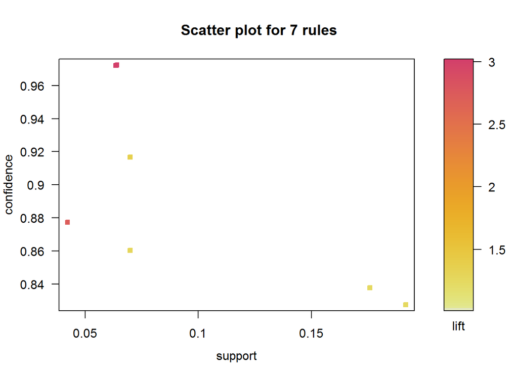

```r
#visualization
library(arulesViz)
plot(rules)
```

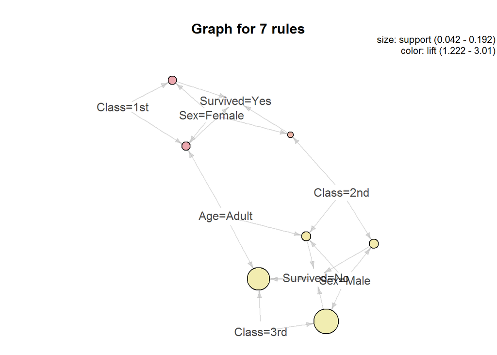

```r
plot(rules, method="graph", control=list(type="items"))
```

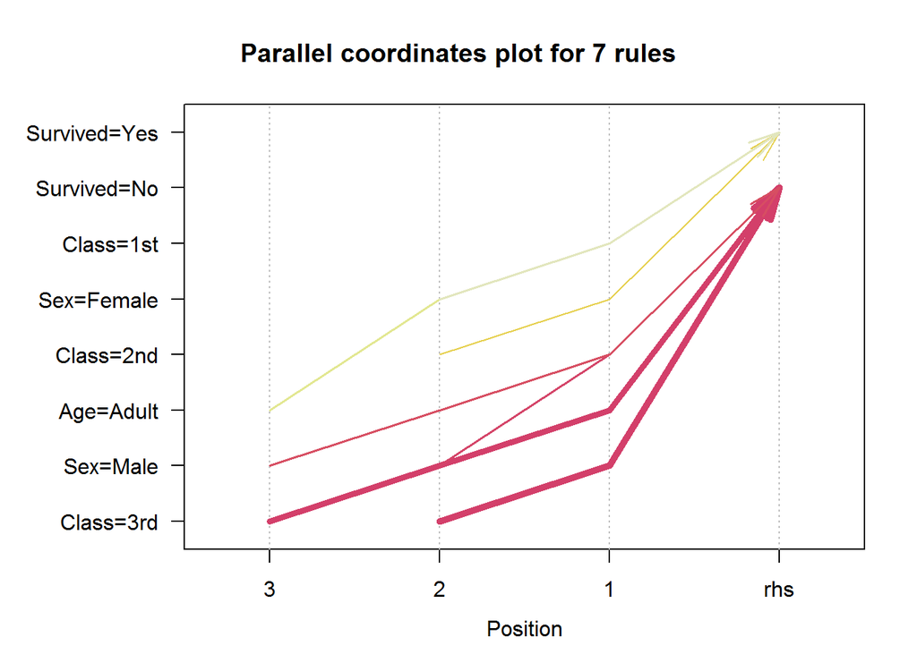

```r
plot(rules, method="paracoord", control=list(reorder=TRUE))
```

5. Report clearly the most “interesting” rules discovered from Titanic data, and how you came up with those in R.

```r
rules <- apriori(titanic, parameter = list(minlen=2, supp=0.005, conf=0.8), appearance =list(rhs=c("Survived=No", "Survived=Yes"), default="lhs"), control = list(verbose=F))

#I will output interestingness based on Lift
sortedrulesdata <- sort(rules, by="lift")
inspect(sortedrulesdata)
```

```
##    lhs                                  rhs            support
## 1  {Class=2nd,Age=Child}             => {Survived=Yes} 0.010904134
## 7  {Class=2nd,Sex=Female,Age=Child}  => {Survived=Yes} 0.005906406
## 4  {Class=1st,Sex=Female}            => {Survived=Yes} 0.064061790
## 10 {Class=1st,Sex=Female,Age=Adult}  => {Survived=Yes} 0.063607451
## 2  {Class=2nd,Sex=Female}            => {Survived=Yes} 0.042253521
## 5  {Class=Crew,Sex=Female}           => {Survived=Yes} 0.009086779
## 11 {Class=Crew,Sex=Female,Age=Adult} => {Survived=Yes} 0.009086779
## 8  {Class=2nd,Sex=Female,Age=Adult}  => {Survived=Yes} 0.036347115
## 9  {Class=2nd,Sex=Male,Age=Adult}    => {Survived=No}  0.069968196
## 3  {Class=2nd,Sex=Male}              => {Survived=No}  0.069968196
## 12 {Class=3rd,Sex=Male,Age=Adult}    => {Survived=No}  0.175829169
## 6  {Class=3rd,Sex=Male}              => {Survived=No}  0.191731031
##    confidence lift
## 1  1.0000000  3.095640
## 7  1.0000000  3.095640
## 4  0.9724138  3.010243
## 10 0.9722222  3.009650
## 2  0.8773585  2.715986
## 5  0.8695652  2.691861
## 11 0.8695652  2.691861
## 8  0.8602151  2.662916
## 9  0.9166667  1.354083
## 3  0.8603352  1.270871
## 12 0.8376623  1.237379
## 6  0.8274510  1.222295
```

```r
## I will calculate hyperconfidence and add it to the quality slot for my sorted rules
quality(sortedrulesdata) <- cbind(quality(sortedrulesdata), hyperConfidence = interestMeasure(rules, measure = "hyperConfidence", transactions = titanic))

## I will output the hyperconfidence in my "interesting" rules also
inspect(head(sort(sortedrulesdata, by = "hyperConfidence")))
```

```
##    lhs                                 rhs            support
## 1  {Class=2nd,Age=Child}            => {Survived=Yes} 0.010904134
## 7  {Class=2nd,Sex=Female,Age=Child} => {Survived=Yes} 0.005906406
## 4  {Class=1st,Sex=Female}           => {Survived=Yes} 0.064061790
## 10 {Class=1st,Sex=Female,Age=Adult} => {Survived=Yes} 0.063607451
## 2  {Class=2nd,Sex=Female}           => {Survived=Yes} 0.042253521
## 5  {Class=Crew,Sex=Female}          => {Survived=Yes} 0.009086779
##    confidence lift     hyperConfidence
## 1  1.0000000  3.095640 0
## 7  1.0000000  3.095640 0
## 4  0.9724138  3.010243 0
## 10 0.9722222  3.009650 0
## 2  0.8773585  2.715986 0
## 5  0.8695652  2.691861 0
```

```r
#I will output interestingness based on hyperConfidence measure for the first five values
hyperconfidence <- sort(sortedrulesdata, by="hyperConfidence")
inspect(hyperconfidence)
```

```
##    lhs                                  rhs            support
## 1  {Class=2nd,Age=Child}             => {Survived=Yes} 0.010904134
## 7  {Class=2nd,Sex=Female,Age=Child}  => {Survived=Yes} 0.005906406
## 4  {Class=1st,Sex=Female}            => {Survived=Yes} 0.064061790
## 10 {Class=1st,Sex=Female,Age=Adult}  => {Survived=Yes} 0.063607451
## 2  {Class=2nd,Sex=Female}            => {Survived=Yes} 0.042253521
## 5  {Class=Crew,Sex=Female}           => {Survived=Yes} 0.009086779
## 11 {Class=Crew,Sex=Female,Age=Adult} => {Survived=Yes} 0.009086779
## 8  {Class=2nd,Sex=Female,Age=Adult}  => {Survived=Yes} 0.036347115
## 9  {Class=2nd,Sex=Male,Age=Adult}    => {Survived=No}  0.069968196
## 3  {Class=2nd,Sex=Male}              => {Survived=No}  0.069968196
## 12 {Class=3rd,Sex=Male,Age=Adult}    => {Survived=No}  0.175829169
## 6  {Class=3rd,Sex=Male}              => {Survived=No}  0.191731031
##    confidence lift     hyperConfidence
## 1  1.0000000  3.095640 0
## 7  1.0000000  3.095640 0
## 4  0.9724138  3.010243 0
## 10 0.9722222  3.009650 0
## 2  0.8773585  2.715986 0
## 5  0.8695652  2.691861 0
## 11 0.8695652  2.691861 0
## 8  0.8602151  2.662916 0
## 9  0.9166667  1.354083 0
## 3  0.8603352  1.270871 0
## 12 0.8376623  1.237379 0
## 6  0.8274510  1.222295 0
```

```r
## Now I will calculate measures of leverage and oddsRatio
interesting <- interestMeasure(rules, c("leverage", "oddsRatio" ), transactions = titanic)
inspect(head(rules))
```

```
##   lhs                        rhs            support     confidence
## 1 {Class=2nd,Age=Child}   => {Survived=Yes} 0.010904134 1.0000000
## 2 {Class=2nd,Sex=Female}  => {Survived=Yes} 0.042253521 0.8773585
## 3 {Class=2nd,Sex=Male}    => {Survived=No}  0.069968196 0.8603352
## 4 {Class=1st,Sex=Female}  => {Survived=Yes} 0.064061790 0.9724138
## 5 {Class=Crew,Sex=Female} => {Survived=Yes} 0.009086779 0.8695652
## 6 {Class=3rd,Sex=Male}    => {Survived=No}  0.191731031 0.8274510
##   lift
## 1 3.095640
## 2 2.715986
## 3 1.270871
## 4 3.010243
## 5 2.691861
## 6 1.222295
```

```r
head(interesting)
```

```
##      leverage oddsRatio
## 1 0.007381718        NA
## 2 0.026696180 17.097461
## 3 0.014912886  3.162994
## 4 0.042780521 91.897368
## 5 0.005711129 14.346358
## 6 0.034869533  2.797348
```

```r
## I will calculate all available measures for the first 5 rules and show them in a table format where the measures are rows
t(interestMeasure(head(rules, 5), transactions = titanic))
```

```
##                              [,1]          [,2]         [,3]          [,4]
## support               0.010904134   0.042253521  0.069968196   0.064061790
## coverage              0.010904134   0.048159927  0.081326670   0.065879146
## confidence            1.000000000   0.877358491  0.860335196   0.972413793
## lift                  3.095639944   2.715985988  1.270870983   3.010242980
## leverage              0.007381718   0.026696180  0.014912886   0.042780521
## hyperLift                     Inf           Inf          Inf           Inf
## hyperConfidence       0.000000000   0.000000000  0.000000000   0.000000000
## fishersExactTest      1.000000000   1.000000000  1.000000000   1.000000000
## improvement                    NA            NA           NA            NA
## chiSquared            0.092412235   0.284375800  0.054446944   0.543982995
## cosine                0.183726085   0.338762411  0.298195490   0.439137284
## conviction                     NA   5.519868591  2.312930486  24.539981826
## gini                  0.010104510   0.031094131  0.005953321   0.059480021
## oddsRatio                      NA  17.097460792  3.162994012  91.897368421
## phi                   0.151996903   0.266634488  0.116669345   0.368776014
## doc                   0.684428112   0.582370424  0.199603247   0.695176439
## RLD                   1.000000000   0.818836267  0.567648053   0.959250174
## imbalance             0.966244726   0.835635359  0.865346535   0.791608392
## kulczynski            0.516877637   0.504080089  0.481845450   0.585363015
## collectiveStrength    0.073620683   0.318245999  0.250182280   0.541830312
## jaccard               0.033755274   0.128453039  0.101650165   0.197202797
## kappa               -10.754928009 -10.505323981 -5.599277186 -10.372813481
## mutualInformation    -0.085706014  -0.095592349 -0.009176430  -0.146620830
## lambda                0.033755274   0.112517581  0.000000000   0.192686357
## jMeasure                       NA   0.032127586  0.007247296   0.064781335
## laplace               0.510671410   0.533153751  0.550410317   0.554997993
## certainty             1.000000000   0.818836267  0.567648053   0.959250174
## addedValue            0.676965016   0.554323506  0.183370180   0.649378809
## ralambrodrainy        0.000000000   0.005906406  0.011358473   0.001817356
## descriptiveConfirm    0.010904134   0.036347115  0.058609723   0.062244434
## confirmedConfidence   1.000000000   0.754716981  0.720670391   0.944827586
## sebag                          NA   7.153846154  6.160000000  35.250000000
## counterexample        1.000000000   0.860215054  0.837662338   0.971631206
## casualSupport         0.333939119   0.359382099  0.735574739   0.385279418
## casualConfidence      1.000000000   0.964768596  0.960889168   0.991696979
## leastContradiction    0.033755274   0.112517581  0.086577181   0.192686357
## centeredConfidence    0.676965016   0.554323506  0.183370180   0.649378809
## varyingLiaison        2.095639944   1.715985988  0.270870983   2.010242980
## yuleQ                          NA   0.889487259  0.519576537   0.978470865
```

[output cut: 31 more lines]

```
## addedValue            0.546530233
## ralambrodrainy        0.001363017
## descriptiveConfirm    0.007723762
## confirmedConfidence   0.739130435
## sebag                 6.666666667
## counterexample        0.850000000
## casualSupport         0.330758746
## casualConfidence      0.966336452
## leastContradiction    0.023909986
## centeredConfidence    0.546530233
## varyingLiaison        1.691860821
## yuleQ                 0.869675919
## yuleY                 0.582259273
## lerman                0.196595379
## implicationIndex     -0.135804753
```

```r
# find redundant rules
subset.matrix <- is.subset(sortedrulesdata, sortedrulesdata)
subset.matrix[lower.tri(subset.matrix, diag=T)] <- NA
redundant <- colSums(subset.matrix, na.rm=T) >= 1
which(redundant)
```

```
##  {Class=2nd,Sex=Female,Age=Child,Survived=Yes}
##                                              2
##  {Class=1st,Sex=Female,Age=Adult,Survived=Yes}
##                                              4
## {Class=Crew,Sex=Female,Age=Adult,Survived=Yes}
##                                              7
##  {Class=2nd,Sex=Female,Age=Adult,Survived=Yes}
##                                              8
```

```r
# remove redundant rules
rules.pruned <- sortedrulesdata[!redundant]
inspect(rules.pruned)
```

```
##    lhs                               rhs            support     confidence
## 1  {Class=2nd,Age=Child}          => {Survived=Yes} 0.010904134 1.0000000
## 4  {Class=1st,Sex=Female}         => {Survived=Yes} 0.064061790 0.9724138
## 2  {Class=2nd,Sex=Female}         => {Survived=Yes} 0.042253521 0.8773585
## 5  {Class=Crew,Sex=Female}        => {Survived=Yes} 0.009086779 0.8695652
## 9  {Class=2nd,Sex=Male,Age=Adult} => {Survived=No}  0.069968196 0.9166667
## 3  {Class=2nd,Sex=Male}           => {Survived=No}  0.069968196 0.8603352
## 12 {Class=3rd,Sex=Male,Age=Adult} => {Survived=No}  0.175829169 0.8376623
## 6  {Class=3rd,Sex=Male}           => {Survived=No}  0.191731031 0.8274510
##    lift     hyperConfidence
## 1  3.095640 0
## 4  3.010243 0
## 2  2.715986 0
## 5  2.691861 0
## 9  1.354083 0
## 3  1.270871 0
## 12 1.237379 0
## 6  1.222295 0
```

6. Continue exploring various interestingness measures - how to describe them the best, using perhaps the scatterplots measuring the effect of each field in the 2x2 tables. (e.g. how would symmetry look like, or other properties).

```r
interestfunc <- function(f11, F1plus, Fplus1){
  interest <- ((10000 * f11)/(F1plus*Fplus1))
  return (interest)
}

convictionfunc <- function(F1plus, Fplus0, f10){
  conviction <- ((F1plus*Fplus0)/(10000 * f10))
  return (conviction)
}

interest <- interestfunc(randomGen[,c(1)], randomGen[,c(5)], randomGen[,c(7)])
conviction <- convictionfunc(randomGen[,c(5)], randomGen[,c(8)], randomGen[,c(3)])



interest <- interestfunc(top10[,c(1)], top10[,c(5)], top10[,c(7)])
conviction <- convictionfunc(top10[,c(5)], top10[,c(8)], top10[,c(3)])



top10 <- cbind(top10, interest)
top10 <- cbind(top10, conviction)
randomGen <- cbind(randomGen, interest)
randomGen <- cbind(randomGen, conviction)
head(top10, 10)
```

```
##       f11  f01  f10  f00 F1plus F0plus Fplus1 Fplus0    T  oddRatio
##  [1,] 464 1856 1392  928   1856   2784   2320   2320 4640 0.6666667
##  [2,] 921 3684 2763 1842   3684   5526   4605   4605 9210 0.6666667
##  [3,] 148  592  444  296    592    888    740    740 1480 0.6666667
##  [4,] 787 3148 2361 1574   3148   4722   3935   3935 7870 0.6666667
##  [5,] 233  932  699  466    932   1398   1165   1165 2330 0.6666667
##  [6,] 606 2424 1818 1212   2424   3636   3030   3030 6060 0.6666667
##  [7,] 887 3548 2661 1774   3548   5322   4435   4435 8870 0.6666667
##  [8,] 556 2224 1668 1112   2224   3336   2780   2780 5560 0.6666667
##  [9,] 656 2624 1968 1312   2624   3936   3280   3280 6560 0.6666667
## [10,] 659 2636 1977 1318   2636   3954   3295   3295 6590 0.6666667
##       jaccard   laplace certainityFactor addedValue  interest conviction
##  [1,]   0.125 0.2502691       0.02343750     0.0180 1.0775862 0.30933333
##  [2,]   0.125 0.2501356      -0.39017609    -0.2105 0.5428882 0.61400000
##  [3,]   0.125 0.2508418       0.19006479     0.1760 3.3783784 0.09866667
##  [4,]   0.125 0.2501587      -0.23660346    -0.1435 0.6353240 0.52466667
##  [5,]   0.125 0.2505353       0.15110357     0.1335 2.1459227 0.15533333
##  [6,]   0.125 0.2502061      -0.07604017    -0.0530 0.8250825 0.40400000
##  [7,]   0.125 0.2501408      -0.34770889    -0.1935 0.5636979 0.59133333
##  [8,]   0.125 0.2502246      -0.03878116    -0.0280 0.8992806 0.37066667
##  [9,]   0.125 0.2501904      -0.11607143    -0.0780 0.7621951 0.43733333
## [10,]   0.125 0.2501895      -0.11856823    -0.0795 0.7587253 0.43933333
```

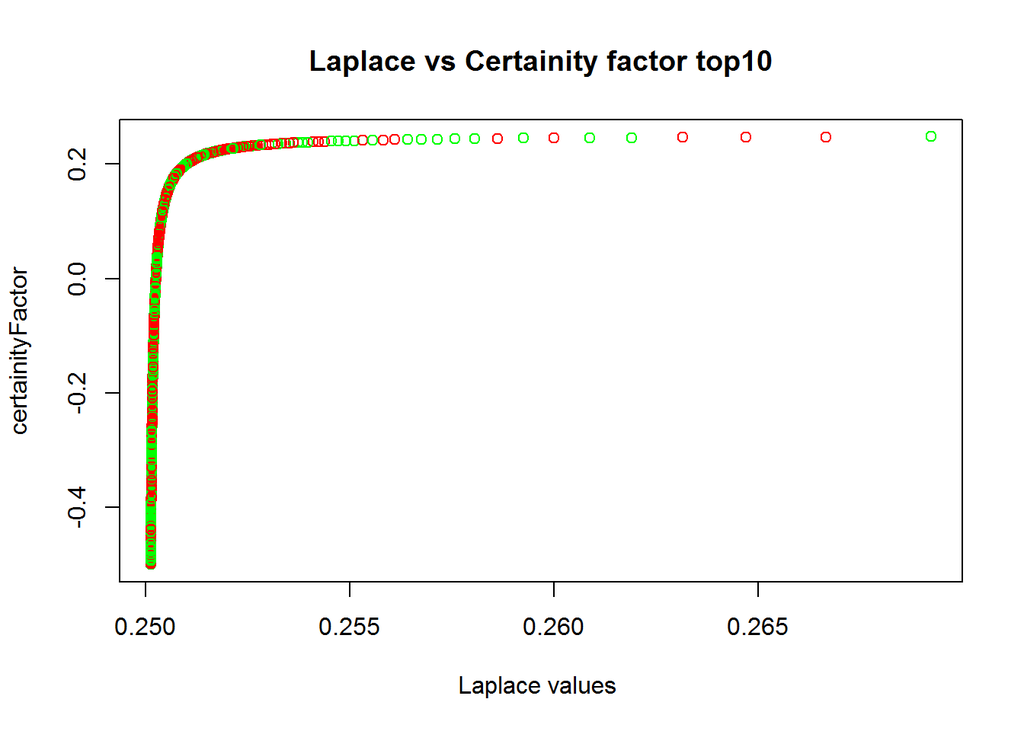

```r
top10df <- as.data.frame(top10)
randomGenNew <- as.data.frame(randomGen)

library(lattice)

plot(x = top10df$laplace, y=top10df$certainityFactor, main="Laplace vs Certainity factor top10", xlab="Laplace values ", ylab="certainityFactor", col=c('Green','Red'))
```

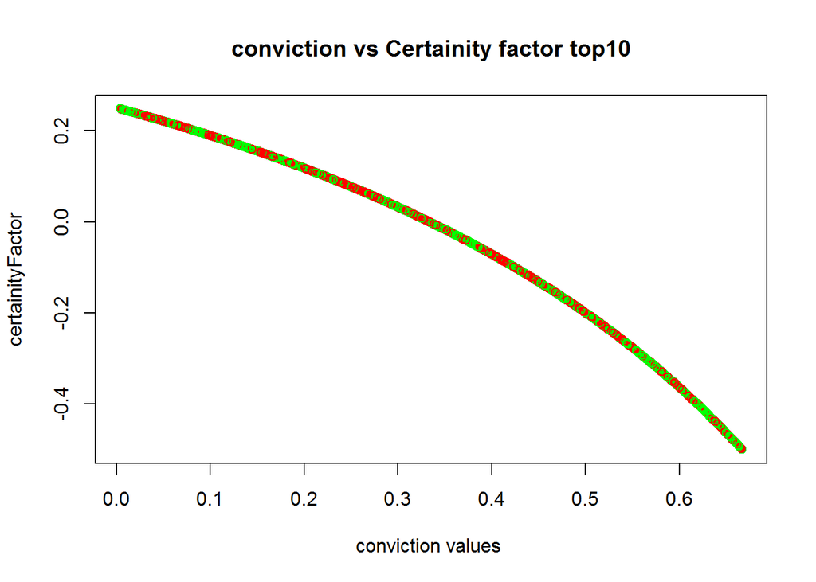

```r
plot(x = top10df$conviction, y=top10df$certainityFactor, main="conviction vs Certainity factor top10", xlab="conviction values ", ylab="certainityFactor", col=c('Green','Red'))
```

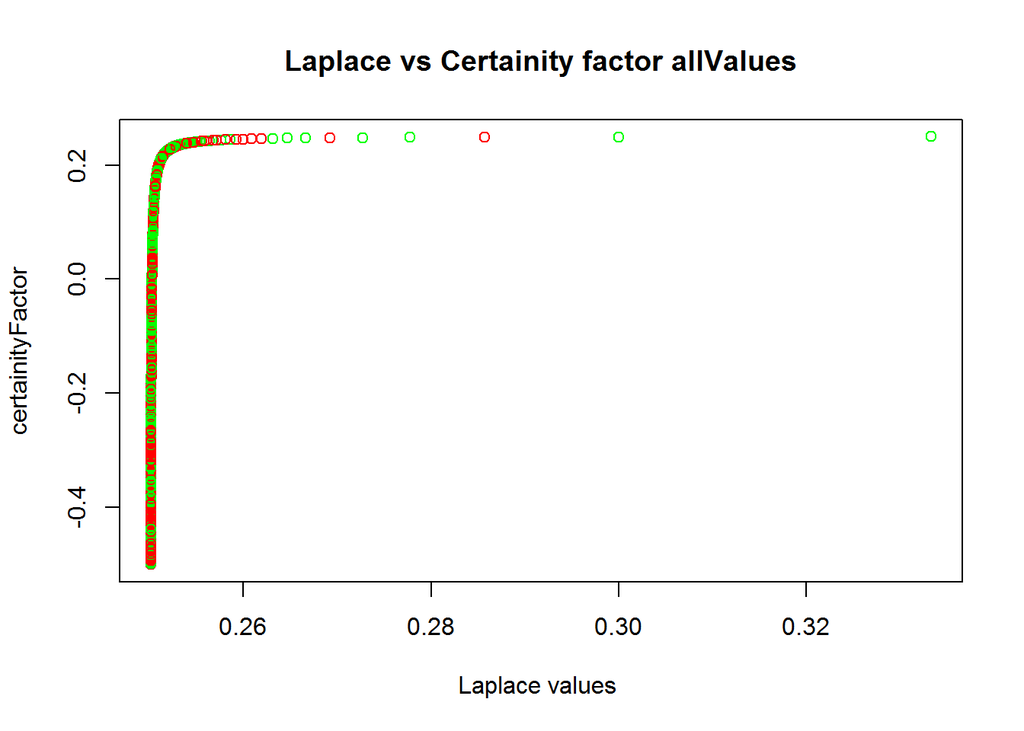

```r
plot(x = randomGenNew$laplace, y=randomGenNew$certainityFactor, main="Laplace vs Certainity factor allValues", xlab="Laplace values ", ylab="certainityFactor", col=c('Green','Red'))
```

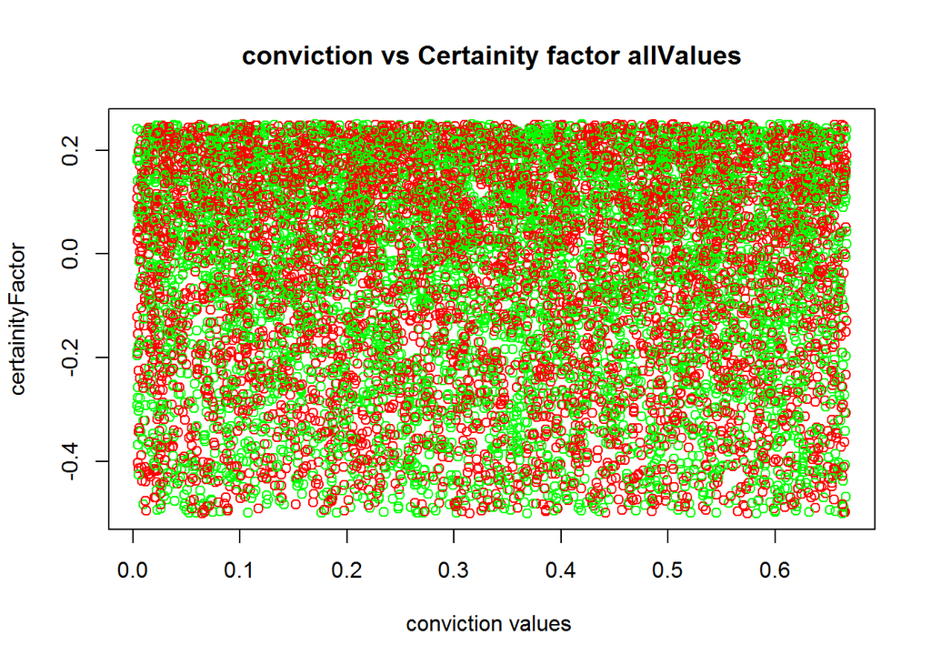

```r
plot(x = randomGenNew$conviction, y=randomGenNew$certainityFactor, main="conviction vs Certainity factor allValues", xlab="conviction values ", ylab="certainityFactor", col=c('Green','Red'))
```